# HSC Survey Results

# Scots Bay Survey # 7 Results from 13/08/2023

## Survey Details

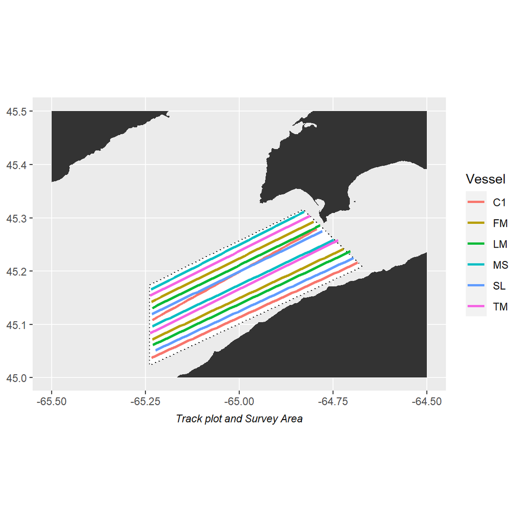

6 commercial purse seiners conducted this fishing survey on 13/08/2023 starting at 20:30:00, which was 2.48 hours before hide tide.

All vessels ran two transects each in the Main Survey Box.

There was a plankton tow and replicate conducted and CTD cast by Lady Melissa.

No tags were applied during this survey.

Samples were obtained for target strength estimation.

### Tides Tables

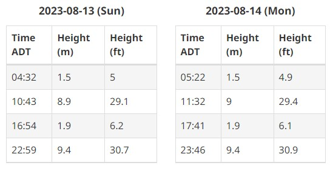

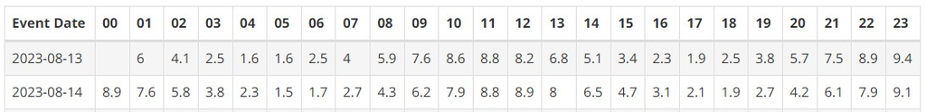

Tide Schedule for Margaretsville NS, Station #315m Source: www.waterlevels.gc.ca

### Acoustic Equipment

Each vessel was equipped with a Simrad ES38-18/200-18C combi (2-in-1) transducer prior to the survey that contains a 38kHz split beam and 200 kHz single beam transducer. Data was logged to the computer hard-drive for post-processing. All participating boats were calibrated on 38kHz before the survey.

## Survey Results

### Main Results

The results are subject to change as DFO will re-evaluate data editing, area estimation and apply a target strength.

**Preliminary biomass prediction for Scots Bay using standardized parallel transects is 4,299mt, and with turnover applied 3,616mt.**

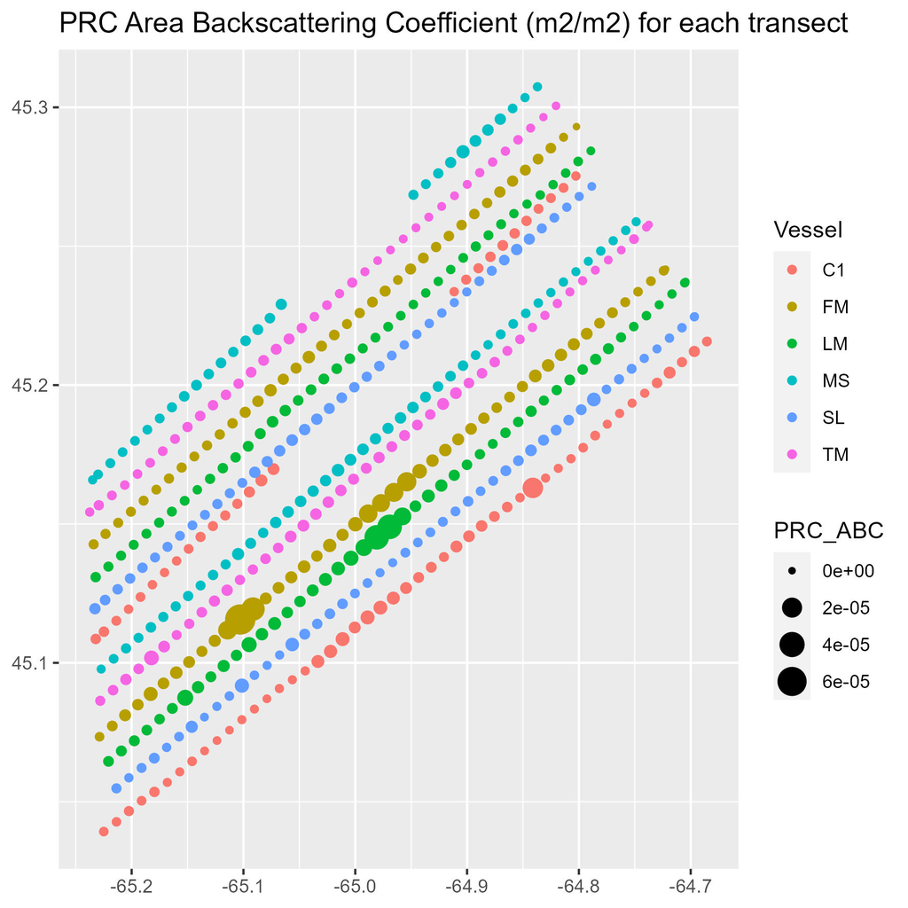

### Transect Details

Table 1: Transect Details

| Vessel | Transect # | Date/Time Start | Date/Time End | Start Lon | Start Lat | End Lon | End Lat | Location | Distance (km) | Speed |
| --- | --- | --- | --- | --- | --- | --- | --- | --- | --- | --- |
| C1 | T01 | 2023-08-14 00:08:31 | 2023-08-14 03:09:16 | -65.235 | 45.037 | -64.685 | 45.216 | SB | 48.88 | 8.76 |
| C1 | T02 | 2023-08-14 04:04:43 | 2023-08-14 06:29:52 | -64.793 | 45.279 | -65.232 | 45.109 | SB | 40.53 | 9.05 |
| FM | T01 | 2023-08-15 01:05:41 | 2023-08-15 03:56:22 | -65.232 | 45.072 | -64.722 | 45.242 | SB | 44.47 | 8.44 |
| FM | T02 | 2023-08-15 04:28:46 | 2023-08-15 06:50:49 | -64.802 | 45.293 | -65.234 | 45.143 | SB | 37.96 | 8.66 |
| LM | T01 | 2023-08-13 23:59:07 | 2023-08-14 02:55:19 | -65.230 | 45.061 | -64.705 | 45.237 | SB | 45.94 | 8.45 |
| LM | T02 | 2023-08-14 03:24:56 | 2023-08-14 05:58:58 | -64.785 | 45.286 | -65.232 | 45.131 | SB | 39.37 | 8.28 |
| MS | T01 | 2023-08-14 00:14:02 | 2023-08-14 02:52:16 | -65.232 | 45.096 | -64.749 | 45.259 | SB | 43.26 | 8.86 |
| MS | T02 | 2023-08-14 03:27:11 | 2023-08-14 05:42:58 | -64.828 | 45.311 | -65.235 | 45.166 | SB | 37.35 | 8.91 |
| SL | T01 | 2023-08-14 01:06:50 | 2023-08-14 04:04:59 | -65.224 | 45.051 | -64.696 | 45.225 | SB | 46.95 | 8.54 |
| SL | T02 | 2023-08-14 04:36:52 | 2023-08-14 07:13:32 | -64.779 | 45.275 | -65.233 | 45.119 | SB | 40.63 | 8.40 |
| TM | T01 | 2023-08-14 00:06:21 | 2023-08-14 03:01:04 | -65.237 | 45.083 | -64.737 | 45.258 | SB | 44.00 | 8.16 |
| TM | T02 | 2023-08-14 03:31:06 | 2023-08-14 05:59:44 | -64.812 | 45.304 | -65.237 | 45.154 | SB | 37.47 | 8.17 |
| NA | NA | NA | NA | NA | NA | NA | NA | SB | NA | NA |
| NA | NA | NA | NA | NA | NA | NA | NA | SB | NA | NA |
| NA | NA | NA | NA | NA | NA | NA | NA | SB | NA | NA |
| NA | NA | NA | NA | NA | NA | NA | NA | SB | NA | NA |
| NA | NA | NA | NA | NA | NA | NA | NA | SB | NA | NA |

### Survey Summary

Table 2: Acoustic Survey Results

| Vessel | Transect No. | Target Strength (db/kg) | Mean Sa (/m2) | Biomass Density (kg/m2) |
| --- | --- | --- | --- | --- |
| FM | T01 | -35.5 | -52.158 | 0.022 |
| LM | T01 | -35.5 | -53.903 | 0.014 |
| C1 | T01 | -35.5 | -57.752 | 0.006 |
| TM | T01 | -35.5 | -58.789 | 0.005 |
| FM | T02 | -35.5 | -59.033 | 0.004 |
| MS | T02 | -35.5 | -59.068 | 0.004 |
| MS | T01 | -35.5 | -59.354 | 0.004 |
| SL | T01 | -35.5 | -59.612 | 0.004 |
| SL | T02 | -35.5 | -59.996 | 0.004 |
| C1 | T02 | -35.5 | -60.298 | 0.003 |
| LM | T02 | -35.5 | -60.659 | 0.003 |
| TM | T02 | -35.5 | -62.007 | 0.002 |
| NA | NA | NA | NA | NA |
| NA | NA | NA | NA | NA |
| NA | NA | NA | NA | NA |
| NA | NA | NA | NA | NA |
| NA | NA | NA | NA | NA |

Note:  
Transects are listed from greatest to least backscatter.

Table 3: Survey Summary Table

| Layer | Target Strength | Area (km2) | Mean Sa | Density (kg/m2) | Biomass (tons) | Percent Area | Percent Biomass | Standard Error (tons) | Standard Error (%) |
| --- | --- | --- | --- | --- | --- | --- | --- | --- | --- |
| Main Box | -35.5 | 661 | -57.3685 | 0.0063 | 4,298.806 | NA | NA | 1,097.66 | 25.53 |
| Northern Box | NA | NA | NA | NA | NA | NA | NA | NA | NA |
| Eastern Box | NA | NA | NA | NA | NA | NA | NA | NA | NA |

### Greatest Backscatter

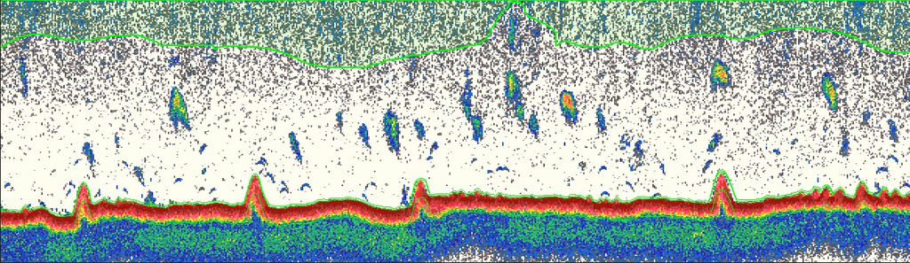

A snip from the transect with the greatest backscatter

The single point with the largest backscatter density (PRC) was recorded by **FM**, at the following location:

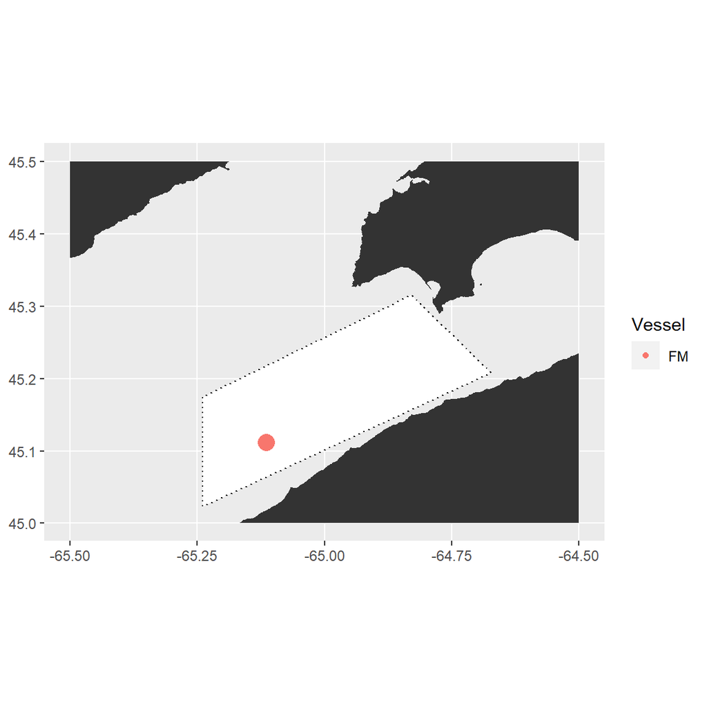

The transect with the overall largest biomass was recorded by **FM**, at the following location:

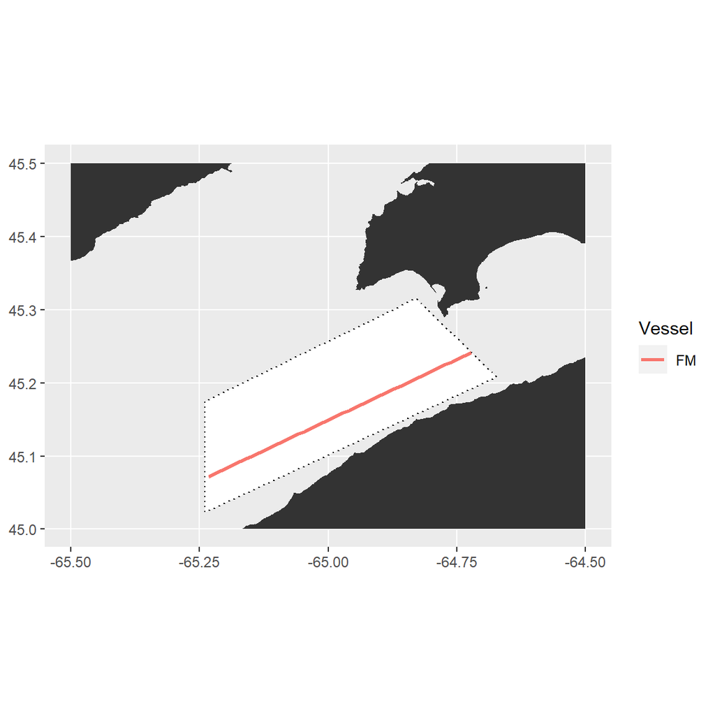

### Annual Summaries

Table 4: Annual Comparison Table

| Ground | Survey Number | Current Year Survey Date | Current Year HSC Estimate | Current Year HSC Turnover Adjusted | Previous Year Survey Date | Previous Year HSC Estimate | Previous Year HSC Turnover Adjusted | Previous Year DFO Estimate | Previous Year DFO Turnover Adjusted |
| --- | --- | --- | --- | --- | --- | --- | --- | --- | --- |
| Scots Bay | 1 | 2023-05-22 | 40,856.000 | 40,856 | 2022-05-29 | 92,542 | 92,542 | 99,092 | 99,092 |
| Scots Bay | 2 | 2023-06-06 | 113,767.329 | 108,783 | 2022-06-12 | 93,163 | 80,663 | 113,792 | 100,407 |
| Scots Bay | 3 | 2023-06-18 | 34,279.387 | 15,158 | 2022-06-26 | 30,535 | 17,624 | 29,429 | 13,709 |
| Scots Bay | 4 | 2023-07-02 | 11,744.776 | 5,113 | 2022-07-10 | 9,886 | 5,432 | 7,892 | 3,515 |
| Scots Bay | 5 | 2023-07-16 | 19,282.634 | 17,575 | 2022-07-26 | 11,954 | 10,869 | 11,402 | 10,536 |
| Scots Bay | 6 | 2023-07-30 | 4,549.933 | 1,904 | 2022-08-07 | 4,900 | 2,901 | 6,150 | 4,248 |
| Scots Bay | 7 | 2023-08-13 | 4,298.806 | 3,616 | 2022-08-21 | 4,094 | 3,225 | 4,688 | 3,656 |
| Scots Bay | 8 | NA | NA | NA | 2022-09-05 | 20,439 | 19,939 | 21,420 | 20,848 |
| Scots Bay | 9 | NA | NA | NA | 2022-09-18 | 7,275 | 4,212 | 7,283 | 0 |
| Scots Bay | 10 | NA | NA | NA | 2022-10-03 | 4,573 | 3,613 | 4,152 | 0 |

Table 5: Annual Summary Table

| Year | Ground | HSC Estimate | HSC Turnover Adjusted | DFO Estimate | DFO Turnover Adjusted |
| --- | --- | --- | --- | --- | --- |
| 2022 | Scots Bay | 279,361.0 | 241,020 | 305,300 | 256,011 |
| 2023 | Scots Bay | 228,778.9 | 193,005 | NA | NA |

## Tagging, Plankton, and CTD Data

### Tag Data

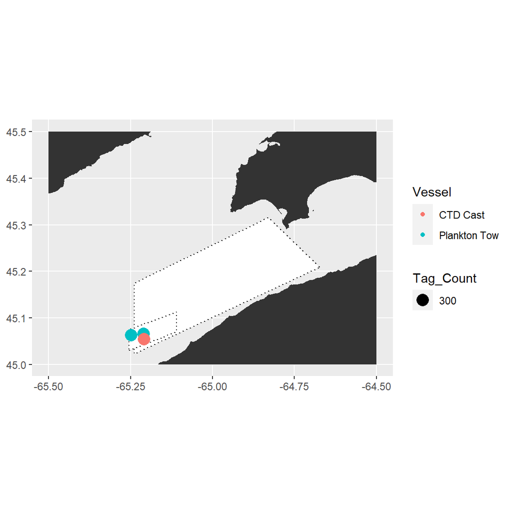

| Vessel | Tags |
| --- | --- |

### Plankton Data

#### Tow Summary Table

|  | Tow 1 | Tow 2 |
| --- | --- | --- |
| **Base Details** |  |  |
| Vessel | Lady Melissa | Lady Melissa |
| Set Number | SB2023-11 | SB2023-12 |
| Ground | SB | SB |
| Date | 13/08/2023 | 13/08/2023 |
| Wind Direction (km/h) | NW | NW |
| Swell (m) | 0 | 0 |
| Air Temp (c) | 21 | 21 |
| **Tow Details** |  |  |
| Tow Start | 19:06:00 | 19:27:00 |
| Tow End | 19:16:00 | 19:37:00 |
| Start Lat | 45.0625 | 45.0660 |
| End Lat | 45.05567 | 45.06033 |
| Start Lon | -65.2485 | -65.2100 |
| End Lon | -65.22383 | -65.22000 |
| Avg Tow Depth (m) | 1.3718477 | 0.9389333 |
| Speed | 6.7 | 3.3 |
| Heading | 60 | 230 |
| Tide Direction | with | against |
| **Other Data Collection** |  |  |
| Flow Start | 600052 | 650367 |
| Flow End | 650367 | 709731 |
| No. Revolutions | 50315 | 59364 |
| Distance (m) | 1352.115 | 1595.289 |
| Volume | 4247.669 | 5011.600 |
| Secchi Disappear (m) | 10 | 10 |
| Secchi Reappear (m) | 9.5 | 9.5 |

#### Tow Depth Profiles

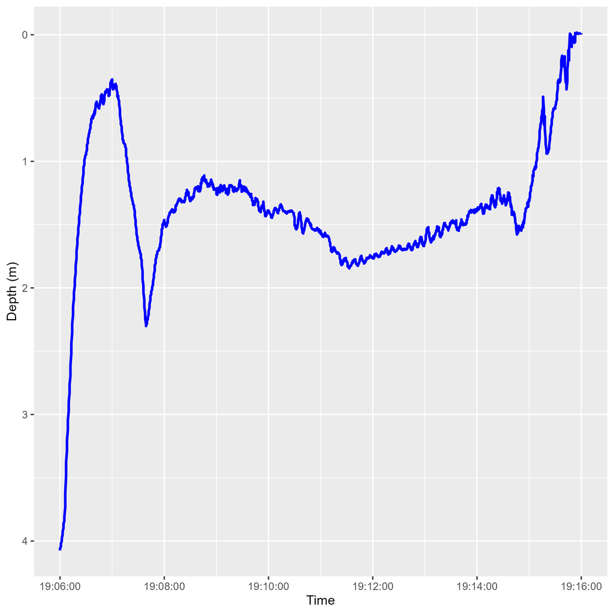

Plankton tow depth profile #1

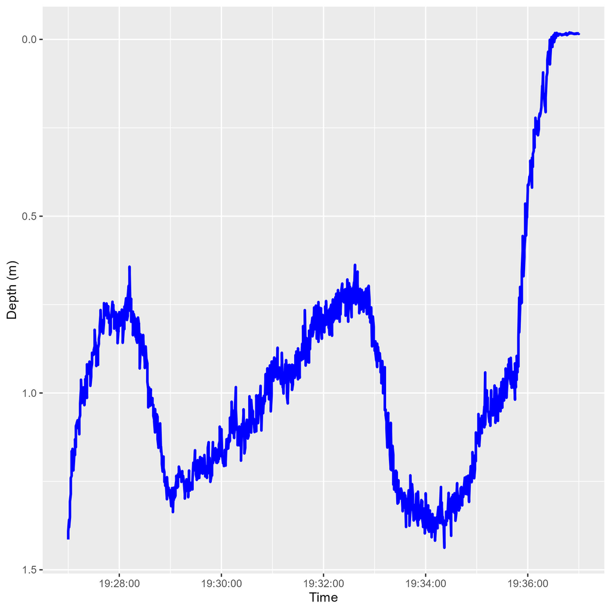

Plankton tow depth profile #2

The first tow is SB2023-11, which was with the tide and had an average depth of 1.3718477m. The second tow is SB2023-12, which was against the tide and had an average depth of 0.9389333m.

#### Captured plankton

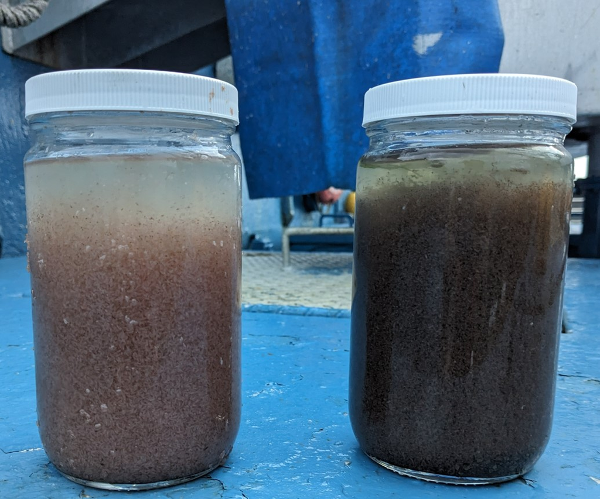

Captured plankton from the surface tows

### CTD Data

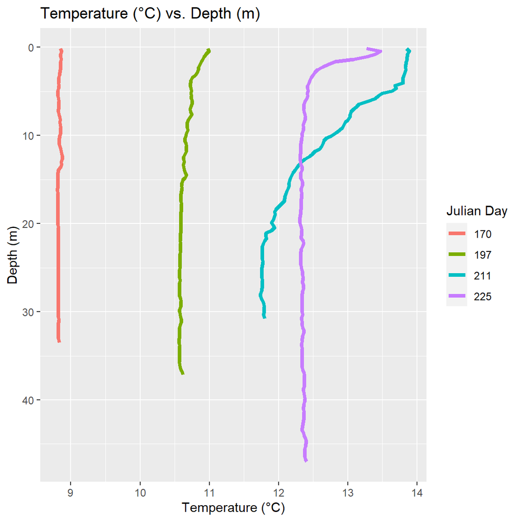

CTD depth profiles for all 2023 Scots Bay surveys so far.

#### Sea surface temperatures

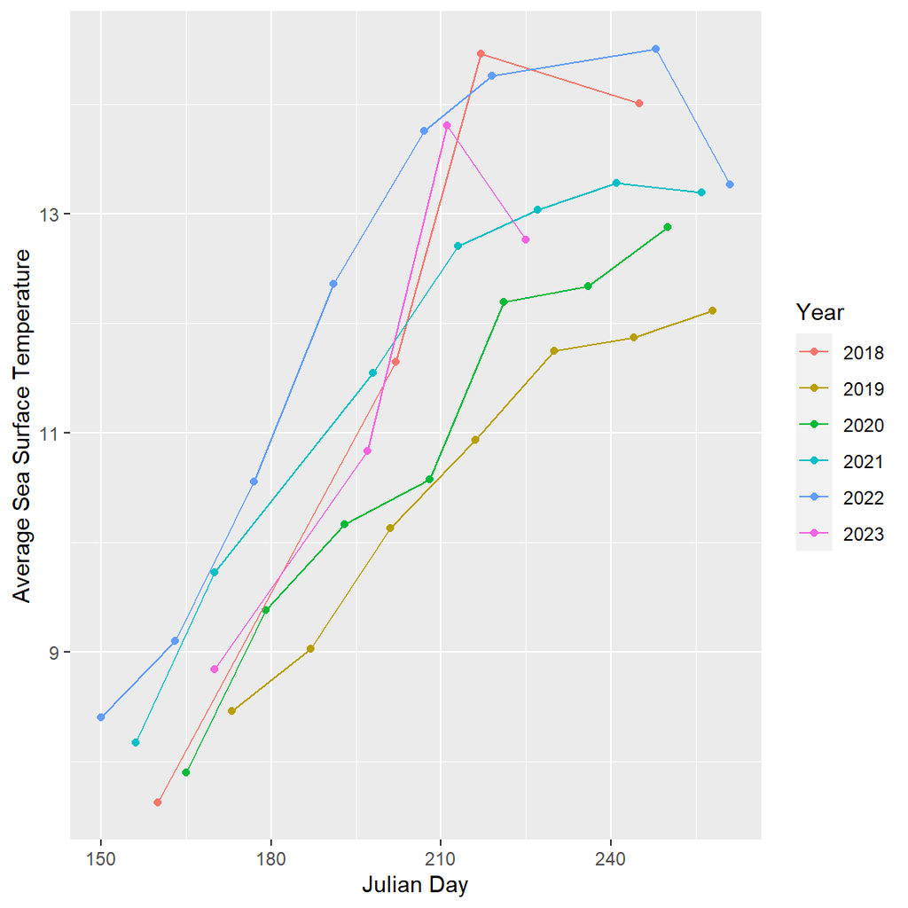

Annual average sea surface temperatures (SST) for Scots Bay.

## Vessel Performance

### Speed

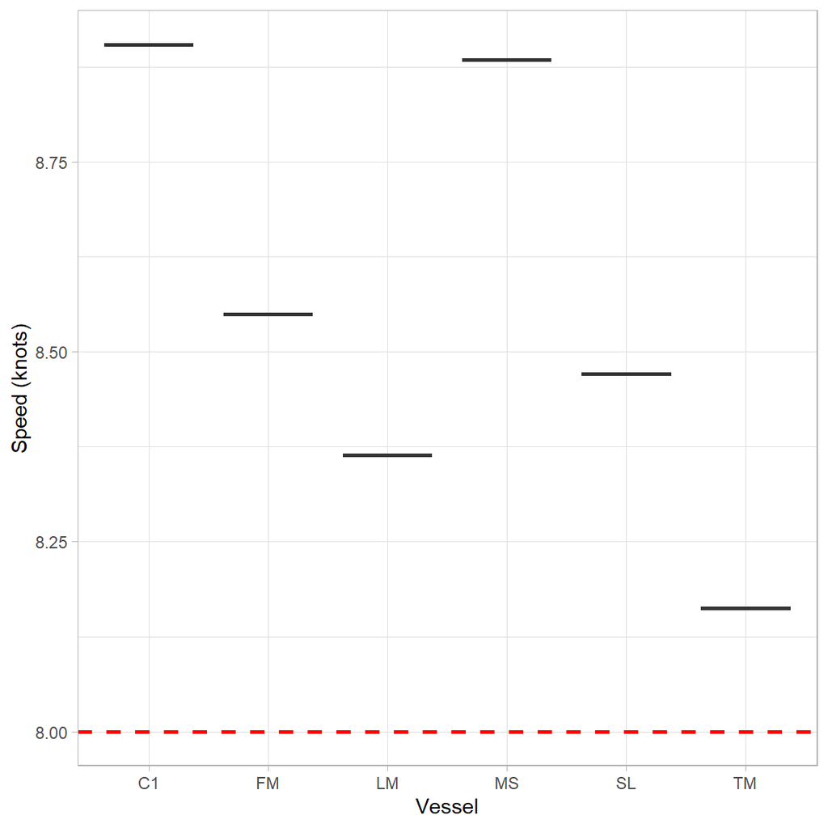

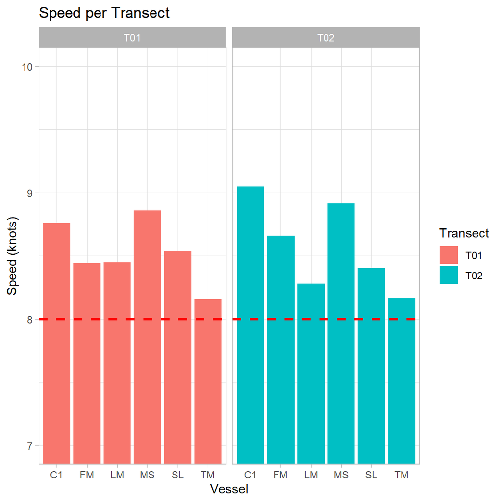

Average vessel speed was 8.56. This is above the 8 knot requirement; vessels are urged to slow down to prevent backscatter noise from interfering with the acoustic data.

### Distance

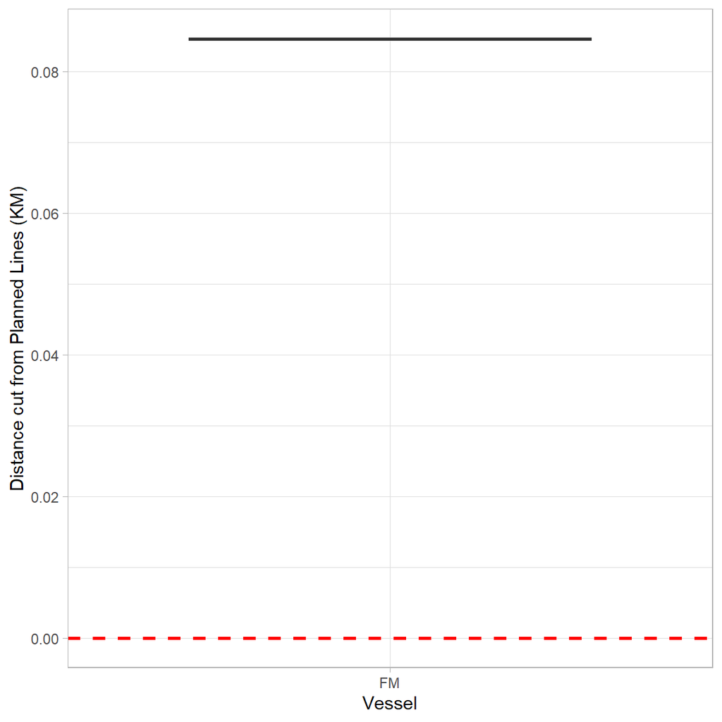

No significant distance was cut from the planned lines; vessels covered the planned area well.